# Time analysis: reproducible script

This notebook presents and allows to reproduce the statistical analysis performed on timing results for the paper: Kowiel, M., Brzezinski, D., Porebski, P.J., Jaskolski, M., Minor, W. Automatic recognition of ligands in electron density by machine learning.

As we do not have any prior assumptions about the distributions of the measured times, we will perform a non-parametric statistical test. Since we are comparing more than two related samples, we will use the Friedman test whose null-hypothesiswhich states that all the measured samples are equivalent. Should the null-hypothesis be rejected, we will proceed with a post-hoc test. We will use the Nemenyi post-hoc test to determine if CheckMyBlob (cmb) is significantly faster than the remaining algorithms (cl, tamc).

```r
library(dplyr)
library(tidyr)
library(PMCMR)
library(scmamp)
library(ggplot2)
```

Below are the raw data gathered during the timing experiment.

```r
data <- read.csv("TimeComparison.csv")
data
```

| pdb | method | time |
| --- | --- | --- |
| 2ev1 | cmb_stacking | 57.03663 |
| 2ev1 | cmb_knn | 42.93807 |
| 2ev1 | cmb_rf | 53.37625 |
| 2ev1 | cmb_lgbm | 43.69004 |
| 2ev1 | cl | 129.98128 |
| 2ev1 | tamc | -1.00000 |
| 4nxk | cmb_stacking | 279.11356 |
| 4nxk | cmb_knn | 266.35982 |
| 4nxk | cmb_rf | 265.22651 |
| 4nxk | cmb_lgbm | 262.13238 |

[output cut: 170 more lines]

Values -1 indicate a timeout of 3600 seconds. We lower bond -1 to 3600 to enable easier visualization and statistical comparison.

```r
data$time[data$time == -1] <- 3600
```

The resulting maens, standard deviations and boxplots are presented below:

```r
data %>%
    select(-pdb) %>%
    group_by(method) %>%
    summarize_all(funs(mean, sd)) %>%
    print()
```

| method | mean | sd |
| --- | --- | --- |
| cl | 251.7255 | 132.33938 |
| cmb_knn | 103.4362 | 63.96081 |
| cmb_lgbm | 105.5179 | 65.17492 |
| cmb_rf | 118.3219 | 67.82440 |
| cmb_stacking | 121.4709 | 65.61846 |
| tamc | 3600.0000 | 0.00000 |

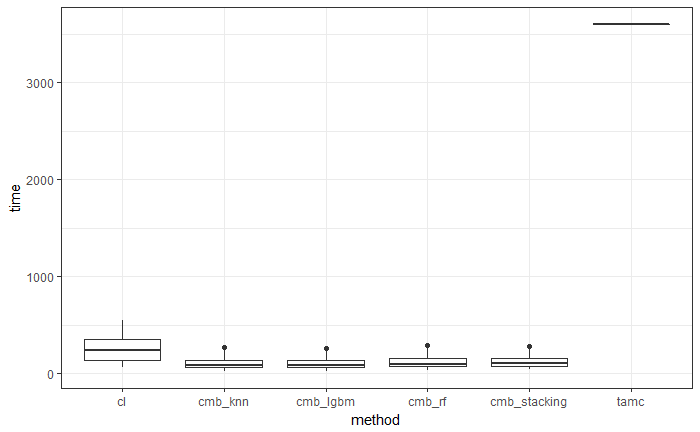

```r
ggplot(data, aes(method, time)) + geom_boxplot() + theme_bw()
```

```r
alpha_level = 0.01
number_of_tests = 4
test_data <- data %>%
    mutate(time = -time) %>%
    spread(method, time) %>%
    select(-pdb) %>%
    as.matrix()
test_result <- friedman.test(test_data, alpha = alpha_level)
test_result
```

```
    Friedman rank sum test

data:  test_data
Friedman chi-squared = 141.22, df = 5, p-value < 2.2e-16
```

Performing the Friedman at significance level alpha=0.01, we can reject the null-hypothesis that the processing times of all three algorithms are equal. The resulting p-value is 9.852014310^{-29}.

Now we will test whether cmb is faster than cl or tamc. For this purpose we will superatlety compare each version of cmb (cmb_knn, cmb_lgbm, cmb_rf, cmb_stacking) against cl and tamc using the Nemenyi post hoc test. Because we will be performing 4 tests, in the following tests we use the Bonferroni correction and divide alpha by 4.

```r
post_hoc_data <- test_data[,c(1,2,6)]
print(posthoc.friedman.nemenyi.test(post_hoc_data, alpha = alpha_level/number_of_tests))
```

```
    Pairwise comparisons using Nemenyi multiple comparison test
             with q approximation for unreplicated blocked data

data:  post_hoc_data

        cl      cmb_knn
cmb_knn 0.00088 -
tamc    0.00019 9.7e-14

P value adjustment method: none
```

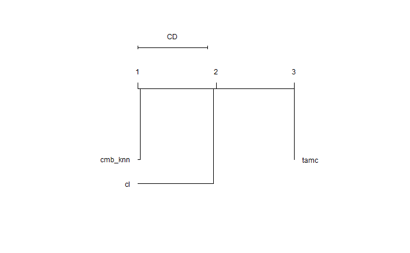

```r
plot = tryCatch({
        plotCD(results.matrix = post_hoc_data, alpha = alpha_level/number_of_tests)
    }, error = function(e) {
        invisible(last_plot())
    })
```

```r
post_hoc_data <- test_data[,c(1,3,6)]
print(posthoc.friedman.nemenyi.test(post_hoc_data, alpha = alpha_level/number_of_tests))
```

```
    Pairwise comparisons using Nemenyi multiple comparison test
             with q approximation for unreplicated blocked data

data:  post_hoc_data

         cl      cmb_lgbm
cmb_lgbm 0.00088 -
tamc     0.00019 9.7e-14

P value adjustment method: none
```

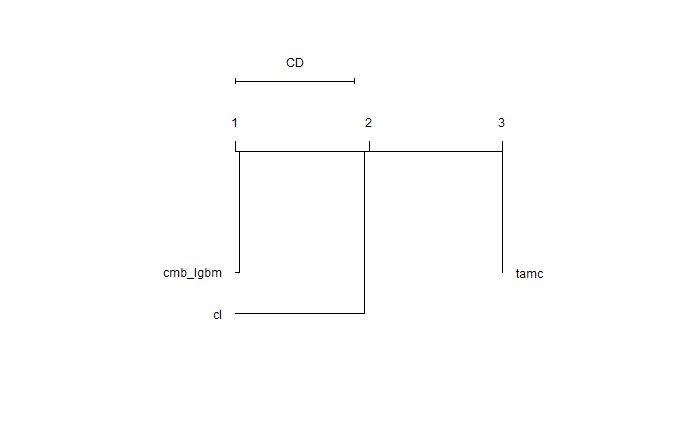

```r
plot = tryCatch({
        plotCD(results.matrix = post_hoc_data, alpha = alpha_level/number_of_tests)
    }, error = function(e) {
        last_plot()
    })
```

```r
post_hoc_data <- test_data[,c(1,4,6)]
print(posthoc.friedman.nemenyi.test(post_hoc_data, alpha = alpha_level/number_of_tests))
```

```
    Pairwise comparisons using Nemenyi multiple comparison test
             with q approximation for unreplicated blocked data

data:  post_hoc_data

       cl      cmb_rf
cmb_rf 0.00088 -
tamc   0.00019 9.7e-14

P value adjustment method: none
```

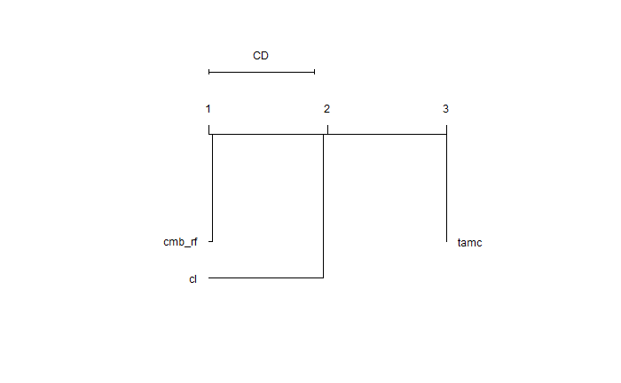

```r
plot = tryCatch({
        plotCD(results.matrix = post_hoc_data, alpha = alpha_level/number_of_tests)
    }, error = function(e) {
        last_plot()
    })
```

```r
post_hoc_data <- test_data[,c(1,5,6)]
print(posthoc.friedman.nemenyi.test(post_hoc_data, alpha = alpha_level/number_of_tests))
```

```
    Pairwise comparisons using Nemenyi multiple comparison test
             with q approximation for unreplicated blocked data

data:  post_hoc_data

             cl      cmb_stacking
cmb_stacking 0.00088 -
tamc         0.00019 9.7e-14

P value adjustment method: none
```

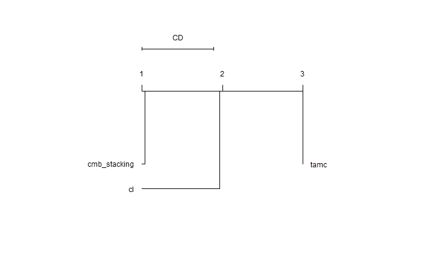

```r
plot = tryCatch({
        plotCD(results.matrix = post_hoc_data, alpha = alpha_level/number_of_tests)
    }, error = function(e) {
        last_plot()
    })
```

The post-hoc tests, visualized using critical distance plots, show that both cl and tamc are significantly slower than any of the cmb implementations.